# Part I - Data Exploration: Communicate Findings via Visualizations

## Multivariate Exploration

#### Question

How long had those whose loan were completed worked in relation to their employment status and number of recommendation? </br>

1. EmploymentStatus - object (qualitative)
2. EmploymentStatusDuration - float64 (quantitative)
3. Recommendations - int64 (quantitative)

#### Visualizations

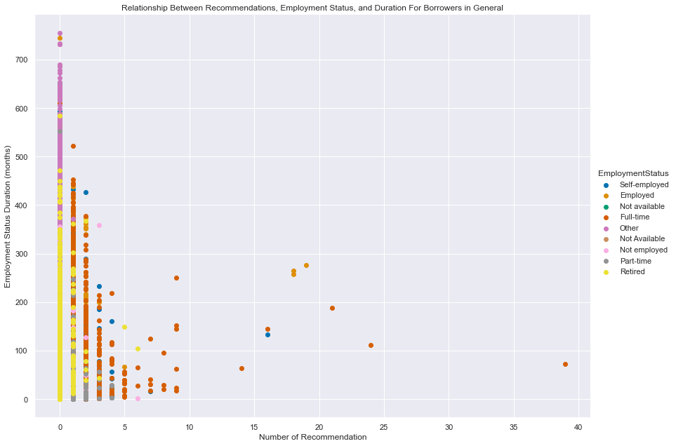

```python
# function to make multivariate plot using facetgrid and matplotlib
def f_plot(dfm, hu, title, x, y):
    # create facetgrid object
    g = sb.FacetGrid(data = dfm,
                 hue = hu,
                 height = 9,
                 aspect = 12/9,
                 palette = 'colorblind').set(
    title = title);

    # create scatter plot
    g.map(plt.scatter,
      'Recommendations',
      'EmploymentStatusDuration');
    plt.ylabel('Employment Status Duration (months)');
    plt.xlabel('Number of Recommendation');
    g.add_legend();

# full scale plot for borrowers in general
f_plot(dff,
       'EmploymentStatus',
      'Relationship Between Recommendations, Employment Status, and Duration For Borrowers in General',
      'Recommendations',
      'EmploymentStatusDuration')
```

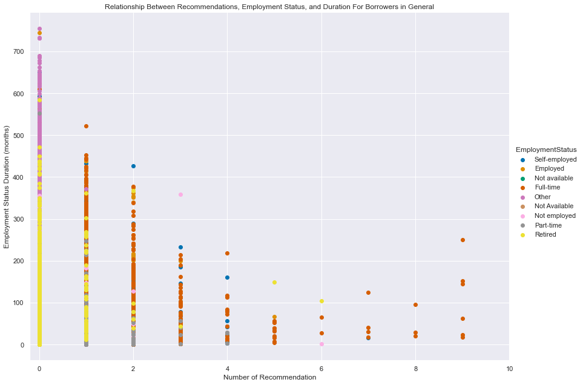

```python
# narrowed scale plot for borrowers in general
f_plot(dff,
       'EmploymentStatus',
      'Relationship Between Recommendations, Employment Status, and Duration For Borrowers in General',
      'Recommendations',
      'EmploymentStatusDuration')
plt.xlim((-0.2,10));
```

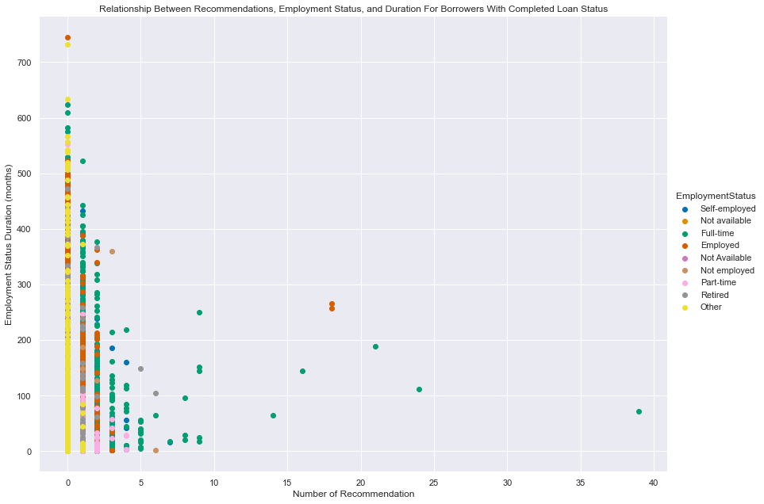

```python
# create sub-df for borrowers with completed loans
completed = dff[
    dff['LoanStatus'] == 'Completed'
];

# multivariate plot for borrowers with completed loan status
f_plot(completed,
       'EmploymentStatus',
      'Relationship Between Recommendations, Employment Status, and Duration For Borrowers With Completed Loan Status',
      'Recommendations',
      'EmploymentStatusDuration')
```

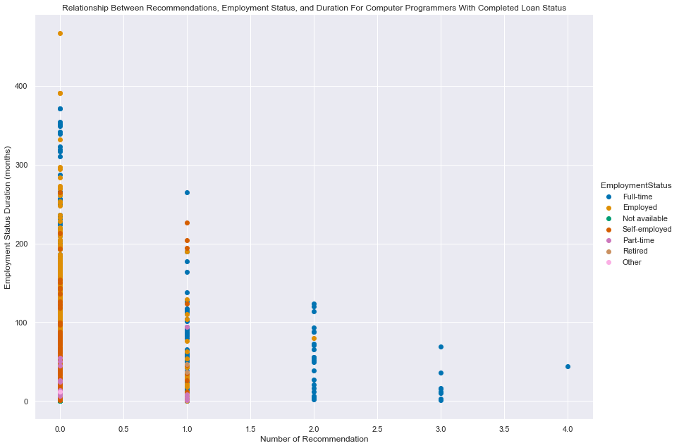

```python
# create sub-df for computer programmers with completed loans.
comp_completed = completed[
    completed['Occupation'] == 'Computer Programmer'
]

# multivariate plot for borrowers with completed loan status
f_plot(comp_completed,
       'EmploymentStatus',
      'Relationship Between Recommendations, Employment Status, and Duration For Computer Programmers \
With Completed Loan Status',
      'Recommendations',
      'EmploymentStatusDuration')
```

#### Question

What was the relationship between DTI, ScorexChangeAtTimeOfListing, and group status of borrowers?

- DebtToIncomeRatio - float64 (quantitative)
- ScorexChangeAtTimeOfListing - float64 (quantitative)
- CurrentlyInGroup - bool (qualitative)

#### Visualizations

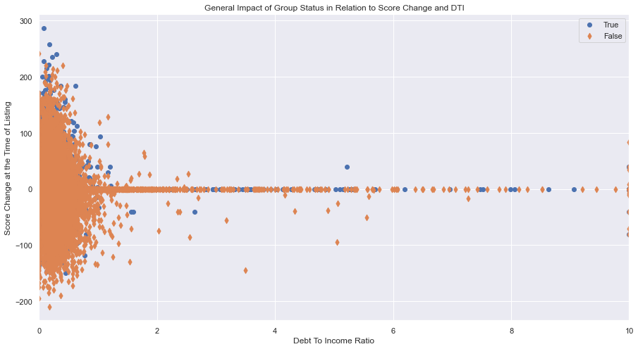

```python
# list of lists containing group status of borrowers
grp_status = [
    [1, 'o'],
    [0, 'd']
]

# function to make multivariate scatter plots for different variables
def g_stats(g_list, gdf, col, g_x, g_y, title, xlim = plt.xlim()):
    for g_value, g_marker in g_list:
        g_df = gdf[gdf[col] == g_value]
        plt.scatter(data = g_df, x = g_x, y = g_y, marker = g_marker);
    plt.ylabel('Score Change at the Time of Listing');
    plt.xlabel('Debt To Income Ratio');
    plt.title(title);
    plt.legend(['True','False']);
    plt.xlim((xlim));

# full scale
g_stats(grp_status, dff, 'CurrentlyInGroup',
        'DebtToIncomeRatio',
        'ScorexChangeAtTimeOfListing',
       'General Impact of Group Status in Relation to Score Change and DTI',
       xlim = (0,10))
```

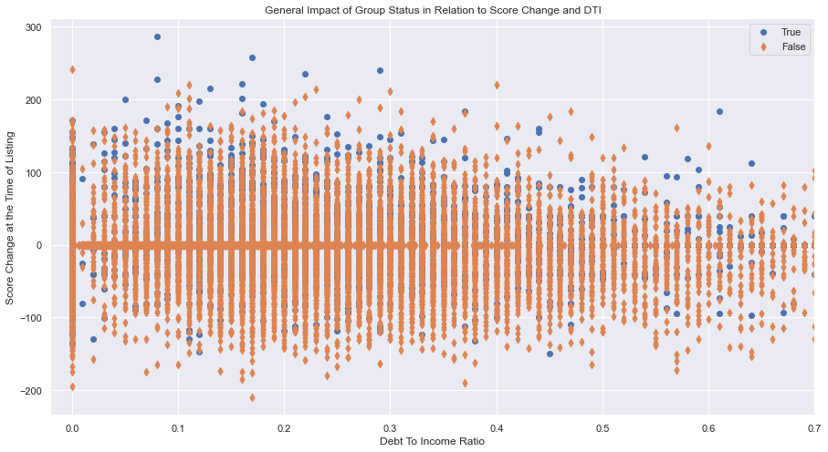

```python
# narrowed scale
g_stats(grp_status, dff, 'CurrentlyInGroup',
        'DebtToIncomeRatio',
        'ScorexChangeAtTimeOfListing',
       'General Impact of Group Status in Relation to Score Change and DTI',
       xlim = (-0.02,0.7))
```

Let's see how this relates to computer programmers alone.

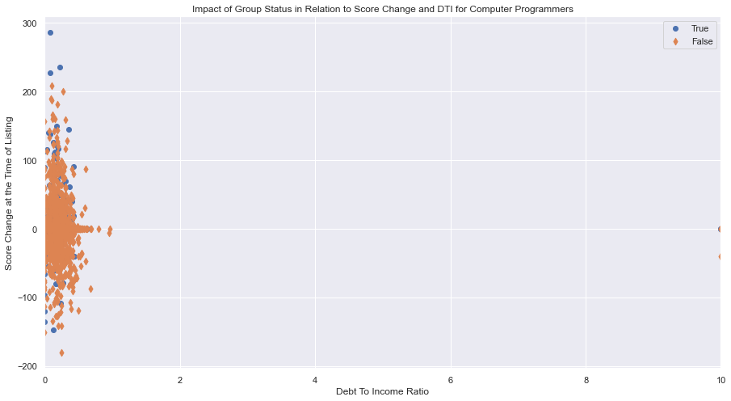

```python
# full scale plot for computer programmers
g_stats(grp_status, occ_comp, 'CurrentlyInGroup',
        'DebtToIncomeRatio',
        'ScorexChangeAtTimeOfListing',
       'Impact of Group Status in Relation to Score Change and DTI for Computer Programmers',
       xlim = (0,10))
```

Again no correlation. Let's narrow the x-scale to get more details.

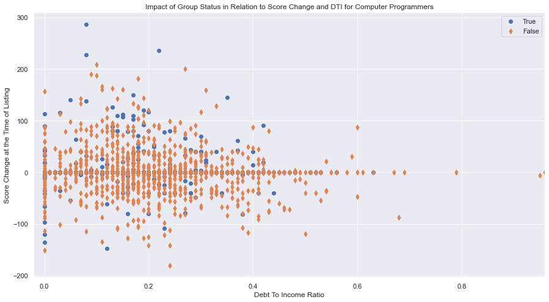

```python
# narrowed scale plot for computer programmers
g_stats(grp_status, occ_comp, 'CurrentlyInGroup',
        'DebtToIncomeRatio',
        'ScorexChangeAtTimeOfListing',
       'Impact of Group Status in Relation to Score Change and DTI for Computer Programmers',
       xlim = (-0.02,0.96))
```

#### Observations

There is clearly no correlation between score change and DTI of borrowers in general. This could mean that the majority of borrowers were not returning customers or the way they managed their income was not determined by their loan status. Let's compare this with that of our top two known borrowers - Professionals and computer programmers. Overall those who belonged to a group happen to have a higher positive score change at the time of listing compared to those who didn't belong to a group. Most computer progrmmers who had a DTI ratio <0.5 did not belong to a group. While those with the highest score change at the time of listing belonged to a group. Belonging to a group may not be a strong factor in getting a loan but it does have a relationship with positive score change at the time of lisitng.

### Talk about some of the relationships you observed in this part of the investigation. Were there features that strengthened each other in terms of looking at your feature(s) of interest?

> Yes. For the visualization between; DTI, ScorexChangeAtTimeOfListing, and group status of borrowers, the DTI ratio and ScorexChangeAtTimeOfListing of borrowers showed a significant overlap even though there exist no correlation between them.

### Were there any interesting or surprising interactions between features?

> Surprising, the number of recommendations didn't have a positive correlation with the employment duration of borrowers and wasn't a determining factor for whether the borrower completed their loan or not.

## Conclusions

- Most loans were taken by full-time working professionals, while students especially those in their early years in college took the least.
- Between 2006 - 2014, the highest number of loans received were recorded between October, 2013 to February, 2014.
- From 2006 to 2014, there was drought in loan funding in the year 2009. Then from 2011, there was an uptrend which experienced an initial slight dip in 2013 before moving upwards to an all time high through to 2014.
- Computer Programmers are the known professionals with the most funding.
- The average monthly income for the top occupation category is about USD7500.
- The category 1 and 12 which represent; debt consolidation and green loans respectively holds the position as the category with the highest and lowest count.
- The top 5 categories for computer programmers that got the most funding starting from the first to the fifth are; 'debt consolidation' (1), 'not available' i.e not stated by the borrower (0), 'other' i.e borrower's option not among those available (7), 'business' (3), and 'home improvement' (2).
- Most borrowers were most likely indebted to other loan lenders before taking this loan judging by the fact that the majority of loans listed were for debt consolidation.
- A good number of top borrowers are past due their payment date by at least 120 days.
- Computer programmer can be seen to have good employment statistics, the majority employed happen to be living in debt with over 6000 currently servicing a loan.
- The majority of workers who had worked the most number of months (>700) had no recommendation.
- While those with the highest score change at the time of listing belonged to a group.
- Belonging to a group may not be a strong factor in getting a loan but it does have a relationship with positive score change at the time of lisitng.

### Limitations:

- Variable to show when a listing was funded was missing. This would have helped the investigation of what variables impacted the successful funding of a listing.
- Listing category should have been a text in string (object) data type rather than integer.